# Introduction to Prophet in R

Nan Hanagud

6/29/2017

# Agenda

- What is Prophet
- Features

# Prophet

- Open Source (CRAN and PyPI)
- Time Series forecasting with model fitting in STAN
- CRAN Package : install.packages(‘prophet’)
- Start here https://facebookincubator.github.io/prophet/
  - Intro for use in R and Python
  - Read the paper

# Capabilities

- Optimized for business forecasts
  - seasonality, irregular holidays, historical trend changes, growth saturation points
- Customizable in ways intuitive to non-experts
  - specify irregular holiday schedules, growth capacities, tweak parameters to fit
- Best with daily data with min one year of historical data.

# The Model

y(t) = g(t) + s(t) + h(t) + ε

g(t): growth function : Logistic growth model with non-constant carrying capacity with changepoints or linear growth model with changepoints. Changepoints are used to model changing rates of growth.

s(t): seasonality (weekly or yearly)

h(t): holidays

ε: error

# Data for this demo

- Fictional Sales Data
- A mostly 5 day week operation
- Standard US holidays are observed

# Data Format

- 2 Columns - ds and y (date and value)
- For a logistic growth model a “cap” field is needed at every row.

```
##        ds                   y
##  Min.   :2015-01-01   Min.   :    0
##  1st Qu.:2015-08-07   1st Qu.:    2
##  Median :2016-03-13   Median : 9839
##  Mean   :2016-03-13   Mean   : 7305
##  3rd Qu.:2016-10-18   3rd Qu.:10925
##  Max.   :2017-05-25   Max.   :14694
```

# Data Graph

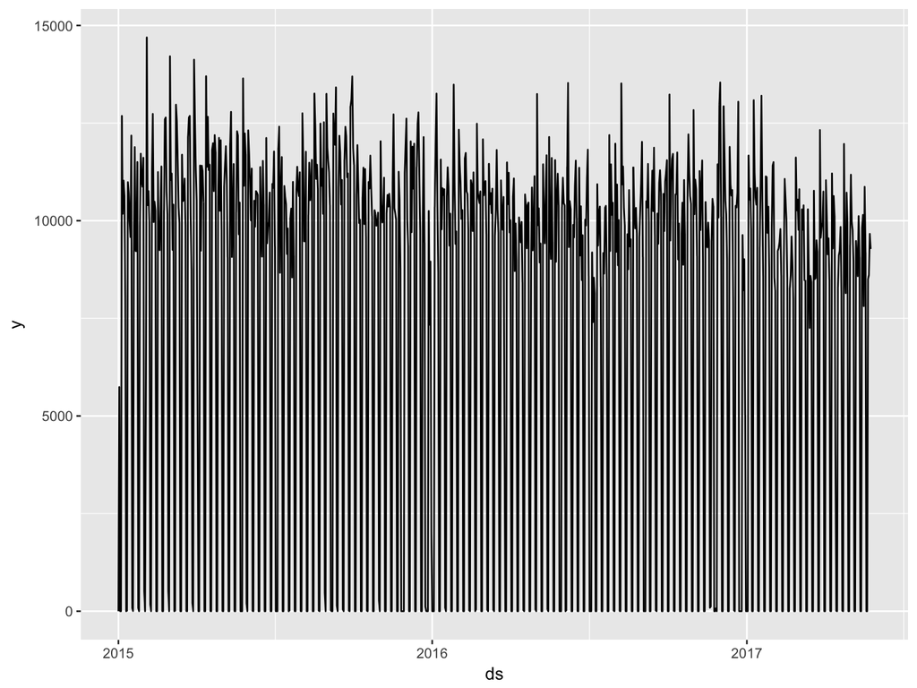

# Training Set

Create a training set - let’s use 2 years so we can let it detect growth/seasonality.

```r
df_train<- df[df$ds < as.Date("2017-01-01"),]
summary(df_train)
```

```
##        ds                   y
##  Min.   :2015-01-01   Min.   :    0
##  1st Qu.:2015-07-02   1st Qu.:    2
##  Median :2016-01-01   Median :10015
##  Mean   :2016-01-01   Mean   : 7384
##  3rd Qu.:2016-07-01   3rd Qu.:11023
##  Max.   :2016-12-31   Max.   :14694
```

# Forecast Assumptions

- Default assumption: Linear
- Can also specify a logistic growth model. Must provide a cap (historical and future)

# Forecast - 30 Days Forward

#### 30 Days forward

> ```
> m <- prophet(df_train)
> future <- make_future_dataframe(m, periods=30)
> forecast <- predict(m,future)
> ```

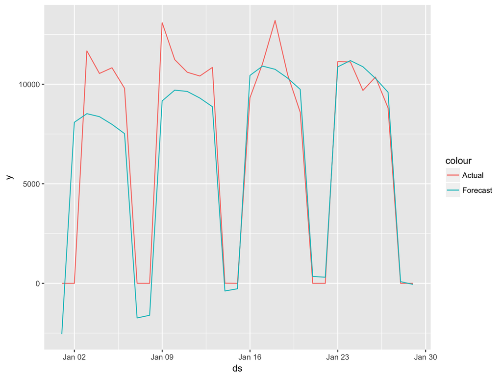

# Forecast - 90 Days Forward

#### 90 Days forward

> ```
> m <- prophet(df_train)
> future <- make_future_dataframe(m, periods=90)
> forecast <- predict(m,future)
> ```

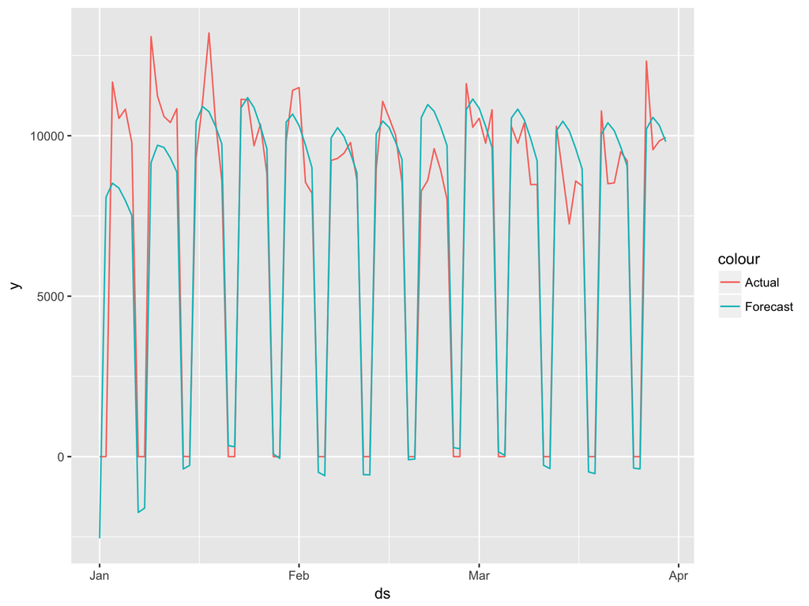

# Performance with Prophet

- MAPE for 30 day prediction: 0.210895
- MAPE for 90 day prediction: 0.1429758

# Performance with Prophet

- Performance of Prophet versus other forecasting methods <sup>1</sup>

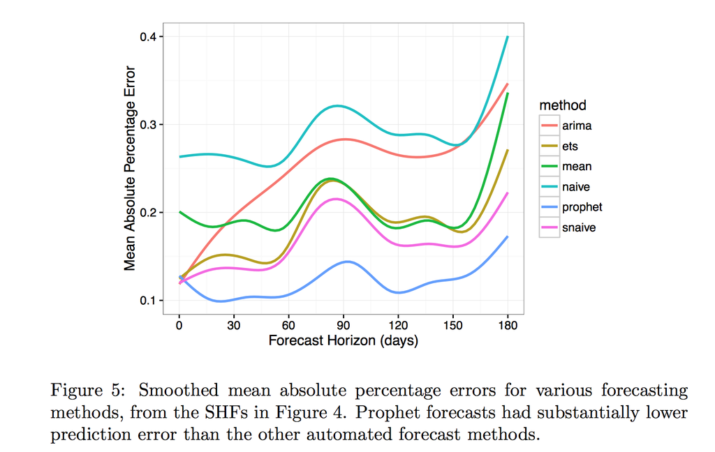

# Forecast - Components

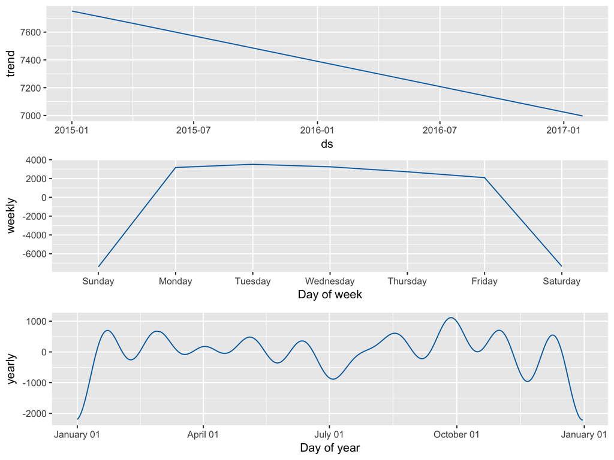

```r
prophet_plot_components(m, forecast)
```

# Trend Changepoints

- Default 25 changepoints first 80% of time series with sparse prior
- Not all changepoints used
- Can specify or have autodetect

# Trend Changepoints

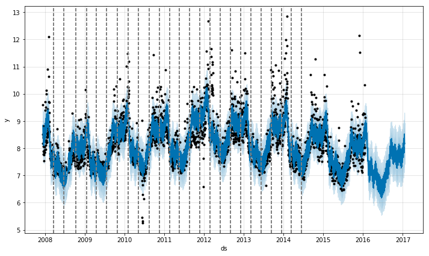

Trend Changepoints (Prohphet Docs)

# Trend Changepoints - Specifying Change Points

Control fit of model via changepoints

- You can:
  - Specify number of changepoints n_changepoints
  - Adjust strength of prior changepoint_prior_scale increase to make flexible
  - Specify location of changepoints changepoints

> ```
> prophet(df_train, changepoint.prior.scale = 0.1)
> ```

- MAPE for 30 day prediction (default changepoint prior=0.05) : 0.210895
- MAPE for 30 day prediction set changepoint prior to 0.1 : 0.2107351

# Forecast Uncertainty

- Sources: trends, seasonality estimates, obervation noise
- Default: Trends (and noise): Compute distribution of historcal trend averages and magnitude
- Seasonality: Requires full [Bayesian Sampling](https://en.wikipedia.org/wiki/Gibbs_sampling), specify a param mcmc_samples

# Forecast Uncertainty Plotted

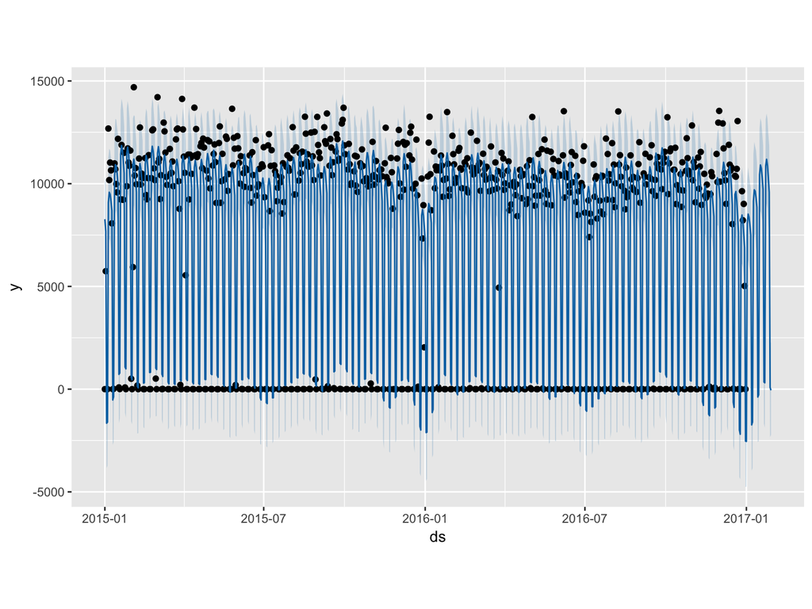

```r
plot(m, forecast)
```

# Seasonality

- Modeled as a fourier series
- Typical Aproximation Terms - 20 (year) and 6 (week)
- Smoothing priors for better fitting (can be specified via the parameter seasonality.prior.scale)

# Holidays

Holidays can be incorporated into the series with a window around it to indicate change of behavior in that time frame

```r
EoYholiday <-data.frame(
  holiday='thanksmas',
ds=as.Date(c('2015-11-26','2015-12-25','2016-11-24','2016-12-25')),
lower_window=1, upper_window=2)

SoYHoliday<-data.frame(
  holiday='memind',
  ds=as.Date(c('2015-1-1','2015-05-25','2015-07-04','2016-1-1','2016-05-30','2016-07-04', '2017-1-1')),
  lower_window=1, upper_window=0)

holidays <- bind_rows(EoYholiday,SoYHoliday)
```

# Forecast with Holidays (90 Days)

> ```
> m <- prophet(df_train, holidays=holidays)
> forecast <- predict(m,future)
> prophet_plot_components(m, forecast)
> ```

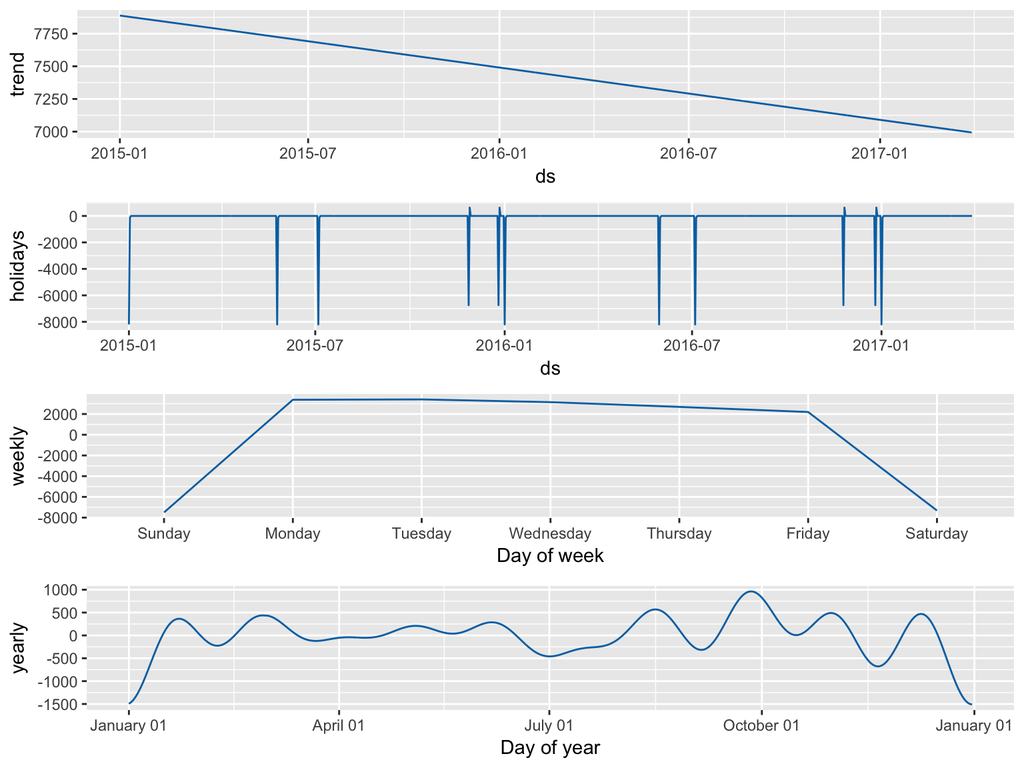

# Forecast with Holidays (90 Days)

- MAPE for 90 day prediction : 0.1429758
- MAPE for 90 day prediction with holidays : 0.1492084

I may have made it worse ¯\*(ツ)*/¯

# Analyst in the loop

prophet(df = df, growth = “linear”, changepoints = NULL, n.changepoints = 25, yearly.seasonality = TRUE, weekly.seasonality = TRUE, holidays = NULL, seasonality.prior.scale = 10, changepoint.prior.scale = 0.05, holidays.prior.scale = 10, mcmc.samples = 0, interval.width = 0.8, uncertainty.samples = 1000, fit = TRUE)

- Capacities a low or declining capacity can be used to adjust the forecast downward or even to produce negative growt e.g. df$cap <- 100 can be specified for every row and is therefore non-constant.
- Changepoints - Known dates of changepoints can be directly specified, such as for example a new product model introduction.
- Holidays and seasonality - Holiday dates and the applicable time scales of seasonality can be added.
- Smoothing parameters - The seasonality (seasonality.prior.scale) and holiday smoothing (holidays.prior.scale) parameters allow the analyst to tell the model how much of the historical seasonal variation is expected in the future.

# References

[1] Taylor, S. J., & Letham, B. (2017, January 13). Forecasting at Scale. Retrieved from https://facebookincubator.github.io/prophet/static/prophet_paper_20170113.pdf

[2] Tutorial: https://facebookincubator.github.io/prophet/docs/installation.html

# Questions / Comments ?

Nan (Nandini) Hanagud

slack me @ nan_hanagud on a2mads